# Lab 3: First contact with dplyr and ggplot2

Stat 133, Spring 2022

### Learning Objectives:

> - Get started with `"dplyr"` and its basic verbs:
>   - `slice()`, `filter()`, `select()`
>   - `mutate()`
>   - `arrange()`
>   - `summarise()`
>   - `group_by()`
> - Get started with `"ggplot2"`
> - Produce basic plots with `ggplot()`

### General Instructions

- Write your descriptions, explanations, and code in an `Rmd` (R markdown) file.
- Name this file as `lab03-first-last.Rmd`, where `first` and `last` are your first and last names (e.g. `lab03-gaston-sanchez.Rmd`).
- Knit your `Rmd` file as an html document (default option).
- Submit your `Rmd` and `html` files to bCourses, in the corresponding lab assignment.

## 1) Manipulating and Visualizing Data Frames

In this lab, you will start learning a couple of approaches to manipulate tables and create statistical graphics. We are going to use the functionality of the *tidyverse* package `"dplyr"` to work with tabular data (*in a syntactic way*).

Likewise, to create graphics in a fairly consistent and visually pleasing way, we are going to use `"ggplot2"` which is another *tidyverse* package.

### 1.1) Installing packages

I’m assuming that you already installed the package `"tidyverse"` which contains `"dplyr"` and `"ggplot2"`. If that’s not the case then **run on the console** the command below (do NOT include this command in your `Rmd`):

```r
# don't include this command in your Rmd file
# don't worry too much if you get a warning message
install.packages("tidyverse")
```

Remember that you only need to install a package once! After a package has been installed in your machine, there is no need to call `install.packages()` again on the same package. What you should always invoke, in order to use the functions in a package, is the `library()` function:

```r
# (include these commands in your Rmd file)
# load the packages
library(tidyverse)
```

**About loading packages:** Another rule to keep in mind is to always load any required packages at the very top of your script files (`.R` or `.Rmd` or `.Rnw` files). Avoid calling the `library()` function in the middle of a script. Instead, load all the packages before anything else.

### 1.2) Data `starwars`

The data file for this lab has to do with Star Wars characters. The dataset is part of the `dplyr` package: `starwars`. So, assuming that you loaded the package `"dplyr"`, then simply type the name of the object: `starwars`

```r
# assuming you loaded dplyr ...
starwars
```

# Part I) Basic `"dplyr"` verbs

To make the learning process of `"dplyr"` gentler, Hadley Wickham proposes beginning with a set of five *basic verbs* or operations for data frames (each verb corresponds to a function in `"dplyr"`):

- **filter**: keep rows matching criteria
- **select**: pick columns by name
- **mutate**: add new variables
- **arrange**: reorder rows
- **summarise**: reduce variables to values

I’ve slightly modified Hadley’s list of verbs:

- `filter()`, `slice()`, and `select()`: subsetting and selecting rows and columns
- `mutate()`: add new variables
- `arrange()`: reorder rows
- `summarise()`: reduce variables to values
- `group_by()`: grouped (aggregated) operations

## 2) Filtering, slicing, and selecting

`slice()` allows you to select rows by position:

```r
# first four rows
four_rows <- slice(starwars, 1:4)
four_rows
```

```
## # A tibble: 4 × 14
##   name      height  mass hair_color skin_color eye_color birth_year sex   gender
##   <chr>      <int> <dbl> <chr>      <chr>      <chr>          <dbl> <chr> <chr>
## 1 Luke Sky…    172    77 blond      fair       blue            19   male  mascu…
## 2 C-3PO        167    75 <NA>       gold       yellow         112   none  mascu…
## 3 R2-D2         96    32 <NA>       white, bl… red             33   none  mascu…
## 4 Darth Va…    202   136 none       white      yellow          41.9 male  mascu…
## # … with 5 more variables: homeworld <chr>, species <chr>, films <list>,
## #   vehicles <list>, starships <list>
```

`filter()` allows you to select rows by defining a condition (which could be simple or compound):

```r
# subset rows given a simple condition
# (height greater than 210 cm)
gt_210 <- filter(starwars, height > 210)
gt_210
```

```
## # A tibble: 7 × 14
##   name      height  mass hair_color skin_color eye_color birth_year sex   gender
##   <chr>      <int> <dbl> <chr>      <chr>      <chr>          <dbl> <chr> <chr>
## 1 Chewbacca    228   112 brown      unknown    blue             200 male  mascu…
## 2 Roos Tar…    224    82 none       grey       orange            NA male  mascu…
## 3 Yarael P…    264    NA none       white      yellow            NA male  mascu…
## 4 Lama Su      229    88 none       grey       black             NA male  mascu…
## 5 Taun We      213    NA none       grey       black             NA fema… femin…
## 6 Grievous     216   159 none       brown, wh… green, y…         NA male  mascu…
## 7 Tarfful      234   136 brown      brown      blue              NA male  mascu…
## # … with 5 more variables: homeworld <chr>, species <chr>, films <list>,
## #   vehicles <list>, starships <list>
```

```r
# subset rows given a compound condition
filter(starwars, height > 210 & mass <= 90)
```

```
## # A tibble: 2 × 14
##   name      height  mass hair_color skin_color eye_color birth_year sex   gender
##   <chr>      <int> <dbl> <chr>      <chr>      <chr>          <dbl> <chr> <chr>
## 1 Roos Tar…    224    82 none       grey       orange            NA male  mascu…
## 2 Lama Su      229    88 none       grey       black             NA male  mascu…
## # … with 5 more variables: homeworld <chr>, species <chr>, films <list>,
## #   vehicles <list>, starships <list>
```

`select()` allows you to select one or more columns by name:

```r
# columns by name
name_mass <- select(starwars, name, mass)
```

### 2.1) Your turn:

1. use `slice()` to subset the data by selecting the first 5 rows.

```r
slice(starwars, 1:5)
```

```
## # A tibble: 5 × 14
##   name      height  mass hair_color skin_color eye_color birth_year sex   gender
##   <chr>      <int> <dbl> <chr>      <chr>      <chr>          <dbl> <chr> <chr>
## 1 Luke Sky…    172    77 blond      fair       blue            19   male  mascu…
## 2 C-3PO        167    75 <NA>       gold       yellow         112   none  mascu…
## 3 R2-D2         96    32 <NA>       white, bl… red             33   none  mascu…
## 4 Darth Va…    202   136 none       white      yellow          41.9 male  mascu…
## 5 Leia Org…    150    49 brown      light      brown           19   fema… femin…
## # … with 5 more variables: homeworld <chr>, species <chr>, films <list>,
## #   vehicles <list>, starships <list>
```

2. use `slice()` to subset the data by selecting rows 3, 6, 9, …, 30. *Optional hint*: `seq()` is your friend.

```r
slice(starwars, seq(3,30,3))
```

```
## # A tibble: 10 × 14
##    name     height  mass hair_color skin_color eye_color birth_year sex   gender
##    <chr>     <int> <dbl> <chr>      <chr>      <chr>          <dbl> <chr> <chr>
##  1 R2-D2        96  32   <NA>       white, bl… red             33   none  mascu…
##  2 Owen La…    178 120   brown, gr… light      blue            52   male  mascu…
##  3 Biggs D…    183  84   black      light      brown           24   male  mascu…
##  4 Wilhuff…    180  NA   auburn, g… fair       blue            64   male  mascu…
##  5 Greedo      173  74   <NA>       green      black           44   male  mascu…
##  6 Jek Ton…    180 110   brown      fair       blue            NA   male  mascu…
##  7 Boba Fe…    183  78.2 black      fair       brown           31.5 male  mascu…
##  8 Lando C…    177  79   black      dark       brown           31   male  mascu…
##  9 Mon Mot…    150  NA   auburn     fair       blue            48   fema… femin…
## 10 Nien Nu…    160  68   none       grey       black           NA   male  mascu…
## # … with 5 more variables: homeworld <chr>, species <chr>, films <list>,
## #   vehicles <list>, starships <list>
```

3. use `slice_tail()` to subset the data by selecting the last 5 rows.

```r
slice_tail(starwars, n=5)
```

```
## # A tibble: 5 × 14
##   name      height  mass hair_color skin_color eye_color birth_year sex   gender
##   <chr>      <int> <dbl> <chr>      <chr>      <chr>          <dbl> <chr> <chr>
## 1 Rey           NA    NA brown      light      hazel             NA fema… femin…
## 2 Poe Dame…     NA    NA brown      light      brown             NA male  mascu…
## 3 BB8           NA    NA none       none       black             NA none  mascu…
## 4 Captain …     NA    NA unknown    unknown    unknown           NA <NA>  <NA>
## 5 Padmé Am…    165    45 brown      light      brown             46 fema… femin…
## # … with 5 more variables: homeworld <chr>, species <chr>, films <list>,
## #   vehicles <list>, starships <list>
```

4. use `filter()` to subset those individuals with mass less than 50 kg.

```r
filter(starwars, mass < 50)
```

```
## # A tibble: 11 × 14
##    name     height  mass hair_color skin_color eye_color birth_year sex   gender
##    <chr>     <int> <dbl> <chr>      <chr>      <chr>          <dbl> <chr> <chr>
##  1 R2-D2        96    32 <NA>       white, bl… red               33 none  mascu…
##  2 Leia Or…    150    49 brown      light      brown             19 fema… femin…
##  3 R5-D4        97    32 <NA>       white, red red               NA none  mascu…
##  4 Yoda         66    17 white      green      brown            896 male  mascu…
##  5 Wicket …     88    20 brown      brown      brown              8 male  mascu…
##  6 Sebulba     112    40 none       grey, red  orange            NA male  mascu…
##  7 Dud Bolt     94    45 none       blue, grey yellow            NA male  mascu…
##  8 Ratts T…     79    15 none       grey, blue unknown           NA male  mascu…
##  9 Wat Tam…    193    48 none       green, gr… unknown           NA male  mascu…
## 10 Sly Moo…    178    48 none       pale       white             NA <NA>  <NA>
## 11 Padmé A…    165    45 brown      light      brown             46 fema… femin…
## # … with 5 more variables: homeworld <chr>, species <chr>, films <list>,
## #   vehicles <list>, starships <list>
```

5. use `filter()` to subset rows with a `sex` category of `none`.

```r
filter(starwars, sex == "none")
```

```
## # A tibble: 6 × 14
##   name   height  mass hair_color skin_color  eye_color birth_year sex   gender
##   <chr>   <int> <dbl> <chr>      <chr>       <chr>          <dbl> <chr> <chr>
## 1 C-3PO     167    75 <NA>       gold        yellow           112 none  masculi…
## 2 R2-D2      96    32 <NA>       white, blue red               33 none  masculi…
## 3 R5-D4      97    32 <NA>       white, red  red               NA none  masculi…
## 4 IG-88     200   140 none       metal       red               15 none  masculi…
## 5 R4-P17     96    NA none       silver, red red, blue         NA none  feminine
## 6 BB8        NA    NA none       none        black             NA none  masculi…
## # … with 5 more variables: homeworld <chr>, species <chr>, films <list>,
## #   vehicles <list>, starships <list>
```

6. use `filter()` to subset rows of individuals with with blond or blonde hair color

```r
filter(starwars, hair_color == "blond" | hair_color == "blonde")
```

```
## # A tibble: 4 × 14
##   name      height  mass hair_color skin_color eye_color birth_year sex   gender
##   <chr>      <int> <dbl> <chr>      <chr>      <chr>          <dbl> <chr> <chr>
## 1 Luke Sky…    172    77 blond      fair       blue            19   male  mascu…
## 2 Anakin S…    188    84 blond      fair       blue            41.9 male  mascu…
## 3 Finis Va…    170    NA blond      fair       blue            91   male  mascu…
## 4 Zam Wese…    168    55 blonde     fair, gre… yellow          NA   fema… femin…
## # … with 5 more variables: homeworld <chr>, species <chr>, films <list>,
## #   vehicles <list>, starships <list>
```

7. use `filter()` and then `select()`, to subset rows of individuals from `Alderaan`, and then display their names.

```r
a <- filter(starwars, homeworld == "Alderaan")
select(a, name)
```

```
## # A tibble: 3 × 1
##   name
##   <chr>
## 1 Leia Organa
## 2 Bail Prestor Organa
## 3 Raymus Antilles
```

8. use `"dplyr"` functions to display the names of individuals with green skin color.

```r
filter(starwars, skin_color == "green")
```

```
## # A tibble: 6 × 14
##   name      height  mass hair_color skin_color eye_color birth_year sex   gender
##   <chr>      <int> <dbl> <chr>      <chr>      <chr>          <dbl> <chr> <chr>
## 1 Greedo       173    74 <NA>       green      black             44 male  mascu…
## 2 Yoda          66    17 white      green      brown            896 male  mascu…
## 3 Bossk        190   113 none       green      red               53 male  mascu…
## 4 Rugor Na…    206    NA none       green      orange            NA male  mascu…
## 5 Kit Fisto    196    87 none       green      black             NA male  mascu…
## 6 Poggle t…    183    80 none       green      yellow            NA male  mascu…
## # … with 5 more variables: homeworld <chr>, species <chr>, films <list>,
## #   vehicles <list>, starships <list>
```

1. find how to `select()` the name, height, and mass, of male individuals, with brown or black hair color.

```r
b <- filter(starwars, sex == "male" & hair_color == "black" | sex == "male" & hair_color == "brown")
select(b, name, height, mass)
```

```
## # A tibble: 20 × 3
##    name                  height  mass
##    <chr>                  <int> <dbl>
##  1 Biggs Darklighter        183  84
##  2 Chewbacca                228 112
##  3 Han Solo                 180  80
##  4 Wedge Antilles           170  77
##  5 Jek Tono Porkins         180 110
##  6 Boba Fett                183  78.2
##  7 Lando Calrissian         177  79
##  8 Arvel Crynyd              NA  NA
##  9 Wicket Systri Warrick     88  20
## 10 Qui-Gon Jinn             193  89
## 11 Watto                    137  NA
## 12 Eeth Koth                171  NA
## 13 Gregar Typho             185  85
## 14 Cliegg Lars              183  NA
## 15 Bail Prestor Organa      191  NA
## 16 Jango Fett               183  79
## 17 Tarfful                  234 136
## 18 Raymus Antilles          188  79
## 19 Finn                      NA  NA
## 20 Poe Dameron               NA  NA
```

10. find how to select the name and homeworld, of human female individuals.

```r
c <- filter(starwars, species == "human" & sex == "female")
select(c, name, homeworld)
```

```
## # A tibble: 0 × 2
## # … with 2 variables: name <chr>, homeworld <chr>
```

## 3) Adding new variables: `mutate()`

Another basic verb is `mutate()` which allows you to add new variables. Let’s create a small data frame for the female individuals with three columns: `name`, `height`, and `mass`:

```r
# creating a small data frame step by step
fem <- filter(starwars, sex == 'female')
fem <- select(fem, name, height, mass)
fem <- slice(fem, c(1, 2, 5, 6, 8))
fem
```

```
## # A tibble: 5 × 3
##   name               height  mass
##   <chr>               <int> <dbl>
## 1 Leia Organa           150  49
## 2 Beru Whitesun lars    165  75
## 3 Ayla Secura           178  55
## 4 Adi Gallia            184  50
## 5 Luminara Unduli       170  56.2
```

Now, let’s use `mutate()` to (temporarily) add a column with the ratio `height / mass`:

```r
mutate(fem, height / mass)
```

You can also give a new name, like: `ht_wt = height / mass`:

```r
mutate(fem, ht_wt = height / mass)
```

In order to permanently change the data, you need to assign the changes to an object:

```r
fem2 <- mutate(fem, ht_m = height * 0.0254, wt_kg = mass * 0.4536)
fem2
```

## 4) Reordering rows: `arrange()`

The next basic verb of `"dplyr"` is `arrange()` which allows you to reorder rows. For example, here’s how to arrange the rows of `fem` by `height`

```r
# order rows by height (increasingly)
arrange(fem, height)
```

By default `arrange()` sorts rows in increasing order. To arrange rows in descending order you need to use the auxiliary function `desc()`.

```r
# order rows by height (decreasingly)
arrange(fem, desc(height))
```

```r
# order rows by height, and then mass
arrange(fem, height, mass)
```

### 4.1) Your Turn:

1. using the data frame `fem`, add a new variable `product` with the product of `height` and `mass`.

```r
mutate(fem, product = height * mass)
```

```
## # A tibble: 5 × 4
##   name               height  mass product
##   <chr>               <int> <dbl>   <dbl>
## 1 Leia Organa           150  49      7350
## 2 Beru Whitesun lars    165  75     12375
## 3 Ayla Secura           178  55      9790
## 4 Adi Gallia            184  50      9200
## 5 Luminara Unduli       170  56.2    9554
```

2. create a new data frame `fem3`, by adding columns `log_height` and `log_mass` with the log transformations of `height` and `mass`.

```r
fem3 <- mutate(fem, log_height = log(height), log_mass = log(mass))
fem3
```

```
## # A tibble: 5 × 5
##   name               height  mass log_height log_mass
##   <chr>               <int> <dbl>      <dbl>    <dbl>
## 1 Leia Organa           150  49         5.01     3.89
## 2 Beru Whitesun lars    165  75         5.11     4.32
## 3 Ayla Secura           178  55         5.18     4.01
## 4 Adi Gallia            184  50         5.21     3.91
## 5 Luminara Unduli       170  56.2       5.14     4.03
```

3. use the original data frame to `filter()` and `arrange()` those individuals with height less than 150 cm tall, in increasing order by height.

```r
d <- filter(starwars, height < 150)
arrange(d, height)
```

```
## # A tibble: 10 × 14
##    name     height  mass hair_color skin_color eye_color birth_year sex   gender
##    <chr>     <int> <dbl> <chr>      <chr>      <chr>          <dbl> <chr> <chr>
##  1 Yoda         66    17 white      green      brown            896 male  mascu…
##  2 Ratts T…     79    15 none       grey, blue unknown           NA male  mascu…
##  3 Wicket …     88    20 brown      brown      brown              8 male  mascu…
##  4 Dud Bolt     94    45 none       blue, grey yellow            NA male  mascu…
##  5 R2-D2        96    32 <NA>       white, bl… red               33 none  mascu…
##  6 R4-P17       96    NA none       silver, r… red, blue         NA none  femin…
##  7 R5-D4        97    32 <NA>       white, red red               NA none  mascu…
##  8 Sebulba     112    40 none       grey, red  orange            NA male  mascu…
##  9 Gasgano     122    NA none       white, bl… black             NA male  mascu…
## 10 Watto       137    NA black      blue, grey yellow            NA male  mascu…
## # … with 5 more variables: homeworld <chr>, species <chr>, films <list>,
## #   vehicles <list>, starships <list>
```

4. display the name, homeworld, and species, of the top-5 tallest individuals.

```r
e <- select(arrange(starwars, desc(height)), name, homeworld, species)
slice(e, 1:5)
```

```
## # A tibble: 5 × 3
##   name         homeworld species
##   <chr>        <chr>     <chr>
## 1 Yarael Poof  Quermia   Quermian
## 2 Tarfful      Kashyyyk  Wookiee
## 3 Lama Su      Kamino    Kaminoan
## 4 Chewbacca    Kashyyyk  Wookiee
## 5 Roos Tarpals Naboo     Gungan
```

5. display the name, homeworld, and species, for the top-5 heaviest individuals.

```r
f <- arrange(starwars, desc(mass))
g <- select(f, name, homeworld, species)
slice(g, 1:5)
```

```
## # A tibble: 5 × 3
##   name                  homeworld species
##   <chr>                 <chr>     <chr>
## 1 Jabba Desilijic Tiure Nal Hutta Hutt
## 2 Grievous              Kalee     Kaleesh
## 3 IG-88                 <NA>      Droid
## 4 Darth Vader           Tatooine  Human
## 5 Tarfful               Kashyyyk  Wookiee
```

## 5) Summarizing values with `summarise()`

The next verb is `summarise()`. Conceptually, this involves applying a function on one or more columns, in order to summarize values. This is probably easier to understand with one example.

Say you are interested in calculating the average height of all individuals. To do this “a la dplyr” you use `summarise()`, or its synonym function `summarize()`:

```r
# average height (removing missing values)
summarise(starwars, avg_height = mean(height, na.rm = TRUE))
```

```
## # A tibble: 1 × 1
##   avg_height
##        <dbl>
## 1       174.
```

What if you want to calculate some summary statistics for `height`: min, median, mean, and max?

```r
# some stats for height (dplyr)
summarise(
  starwars,
  min = min(height, na.rm = TRUE),
  median = median(height, na.rm = TRUE),
  avg = mean(height, na.rm = TRUE),
  max = max(height, na.rm = TRUE)
)
```

```
## # A tibble: 1 × 4
##     min median   avg   max
##   <int>  <int> <dbl> <int>
## 1    66    180  174.   264
```

## 6) Grouped operations

To actually appreciate the power of `summarise()`, we need to introduce the other major basic verb in `"dplyr"`: `group_by()`. This is the function that allows you to perform data aggregations, or *grouped operations*.

```r
# average height, grouped by homeworld
summarise(
  group_by(starwars, homeworld),
  avg_salary = mean(height, na.rm = TRUE)
)
```

Here’s a more fancy example: average mass and height, by homeworld, displayed in desceding order by average height:

```r
arrange(
  summarise(
    group_by(starwars, homeworld),
    avg_height = mean(height, na.rm = TRUE),
    avg_mass = mean(mass, na.rm = TRUE)),
  desc(avg_height)
)
```

### 6.1) Your turn:

1. use `summarise()` to get the largest height value.

```r
summarise(starwars, max = max(height, na.rm = TRUE))
```

```
## # A tibble: 1 × 1
##     max
##   <int>
## 1   264
```

2. use `summarise()` to get the standard deviation of `mass`.

```r
summarise(starwars, sd(mass, na.rm = TRUE))
```

```
## # A tibble: 1 × 1
##   `sd(mass, na.rm = TRUE)`
##                      <dbl>
## 1                     169.
```

3. use `summarise()` and `group_by()` to display the median of mass, by homeworld

```r
summarise(
  group_by(starwars, homeworld),
  med = median(mass, na.rm = TRUE)
)
```

```
## # A tibble: 49 × 2
##    homeworld        med
##    <chr>          <dbl>
##  1 Alderaan        64
##  2 Aleen Minor     15
##  3 Bespin          79
##  4 Bestine IV     110
##  5 Cato Neimoidia  90
##  6 Cerea           82
##  7 Champala        NA
##  8 Chandrila       NA
##  9 Concord Dawn    79
## 10 Corellia        78.5
## # … with 39 more rows
```

4. display the average mass by gender, in ascending order,

```r
summarise(
  group_by(starwars, gender),
  avg_mass = mean(mass, na.rm=TRUE)
)
```

```
## # A tibble: 3 × 2
##   gender    avg_mass
##   <chr>        <dbl>
## 1 feminine      54.7
## 2 masculine    106.
## 3 <NA>          48
```

5. obtain the mean and standard deviation of `height`, for female characters.

```r
summarise(
  filter(starwars, sex == "female"),
  avg_ht = mean(height, na.rm = TRUE),
  sd_ht = sd(height, na.rm = TRUE)
)
```

```
## # A tibble: 1 × 2
##   avg_ht sd_ht
##    <dbl> <dbl>
## 1   169.  15.3
```

# Part II) First contact with `ggplot()`

The package `"ggplot2"` is probably the most popular package in R to create *beautiful* static graphics. Compared to the functions in the base package `"graphics"`, the package `"ggplot2`” follows a somewhat different philosophy, and it tries to be more consistent and modular as possible.

- The main function in `"ggplot2"` is `ggplot()`
- The main input to `ggplot()` is a data frame object.
- You can use the internal function `aes()` to specify what columns of the data frame will be used for the graphical elements of the plot.
- You must specify what kind of *geometric objects* or **geoms** will be displayed: e.g. `geom_point()`, `geom_bar()`, `geom_boxpot()`.
- Pretty much anything else that you want to add to your plot is controlled by auxiliary functions, especially those things that have to do with the format, rather than the underlying data.
- The construction of a ggplot is done by *adding layers* with the `+` operator.

## 7) Scatterplots

Let’s start with a scatterplot of `height` and `mass`

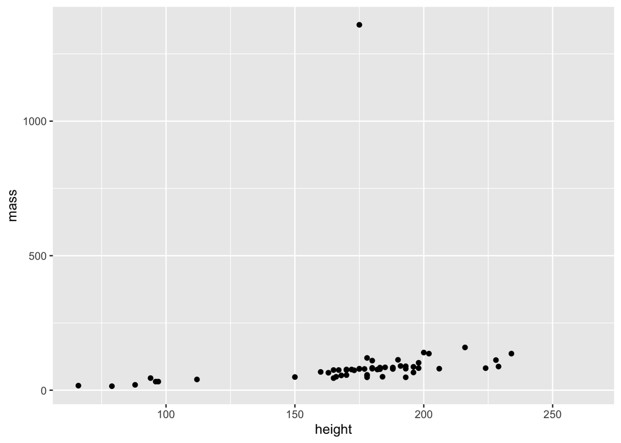

```r
# scatterplot (option 1)
ggplot(data = starwars) +
  geom_point(aes(x = height, y = mass))
```

The same scatterplot can also be created with this alternative, and more common use of `ggplot()`

```r
# scatterplot (option 2)
ggplot(data = starwars, aes(x = height, y = mass)) +
  geom_point()
```

### 7.1) Adding color

Say you want to color code the points in terms of `sex`

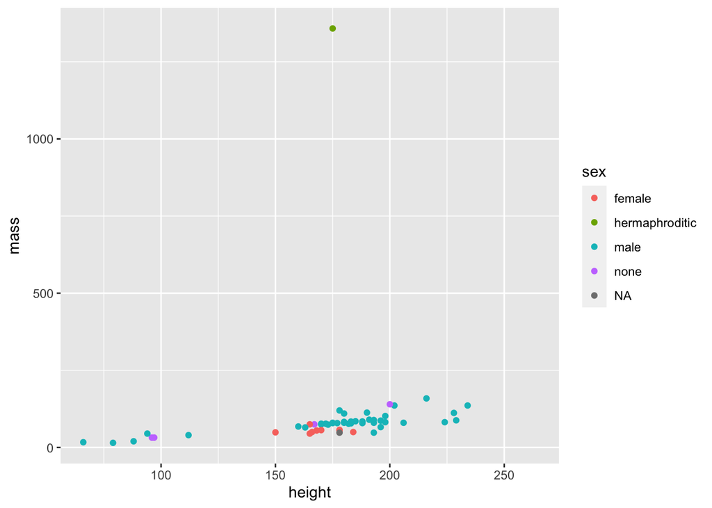

```r
# colored scatterplot
ggplot(data = starwars, aes(x = height, y = mass)) +
  geom_point(aes(color = sex))
```

### 7.2) Your turn:

Open the ggplot2 cheatsheet.

1. Use the data frame `fem` to make a scatterplot of `height` and `mass`.

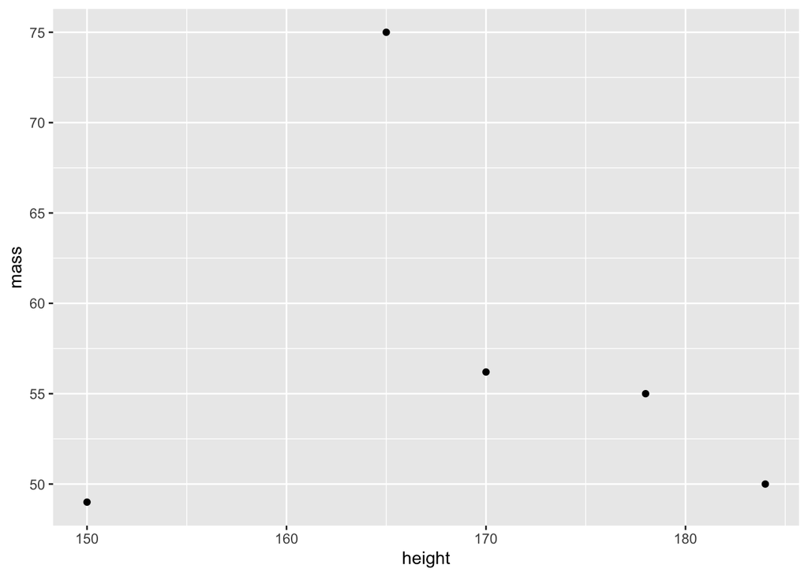

```r
ggplot(data = fem, aes(x=height, y=mass)) + geom_point()
```

2. Find out how to make another scatterplot of `height` and `mass`, using `geom_text()` to display the names of the individuals

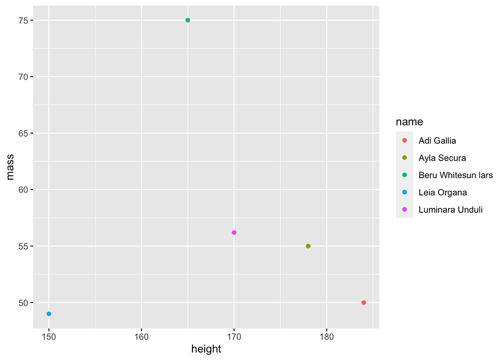

```r
ggplot(data = fem, aes(x=height, y=mass)) + geom_point(aes(color = name))
```

3. Get a scatter plot of `height` and `mass`, for ALL the females, displaying their names with `geom_label()`.

[figure not shown]

```r
all_fem = filter(starwars, sex == "female")
ggplot(data = all_fem, aes(x = height, y = mass)) + geom_point() + geom_label(aes(label = name))
```

4. Get a histogram of `mass` (for all individuals).

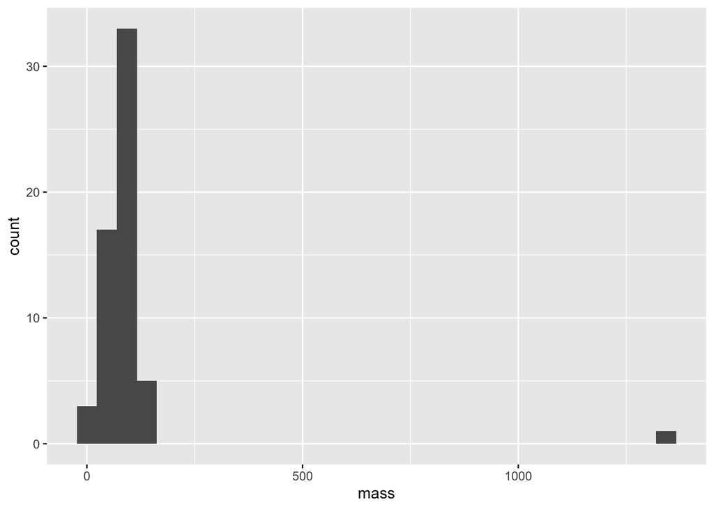

```r
ggplot(starwars, aes(x = mass)) + geom_histogram()
```

5. Get a density plot of `height` (for all individuals).

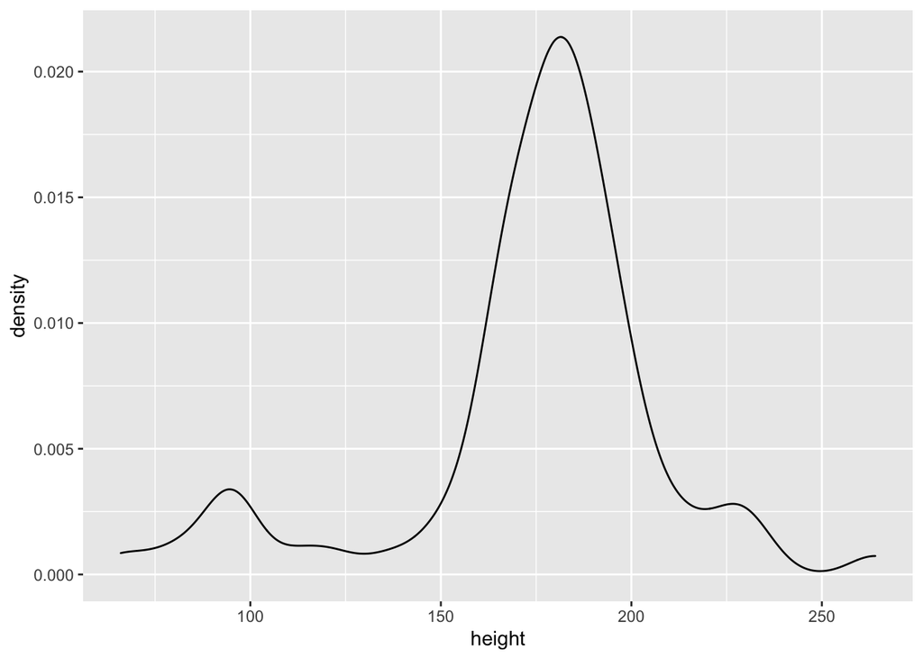

```r
ggplot(starwars, aes(x = height)) + geom_density()
```

6. Get a barchart of the `sex` frequencies (for all individuals).

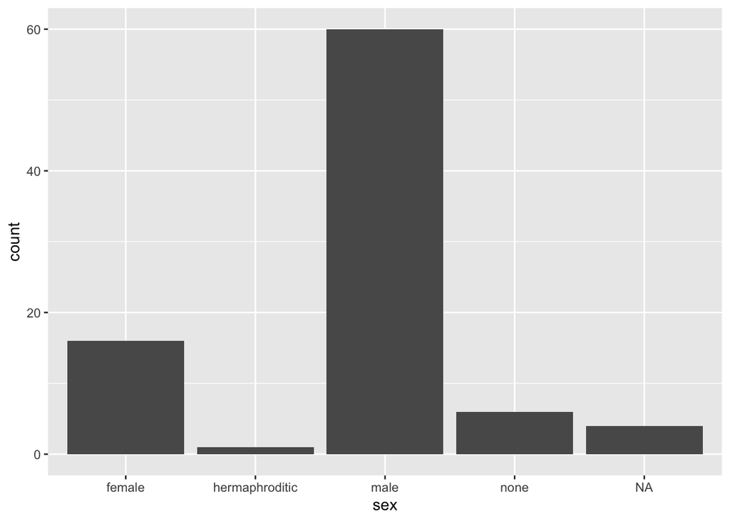

```r
ggplot(starwars, aes(x = sex)) + geom_bar()
```